# Chapter 9 The Instruments of Trade Policy

# Preview

- Partial equilibrium analysis of tariffs in a single industry: supply, demand, and trade
- Costs and benefits of tariffs
- Export subsidies
- Import quotas
- Voluntary export restraints
- Local content requirements

# Basic Tariff Analysis

# Types of Tariffs

- A tariff is a tax levied when a good is imported.
- A **specific tariff** is levied as a fixed charge for each unit of imported goods.
  - For example, $3 per barrel of oil.
- An **ad valorem tariff** is levied as a fraction of the value of imported goods.
  - For example, 25% tariff on the value of imported trucks.

# Supply, Demand, and Trade in a Single Industry

- Consider how a tariff affects a single market, say that of wheat.
- Suppose that in the absence of trade the price of wheat is higher in Home than it is in Foreign.
- With trade, wheat will be shipped from Foreign to Home until the price difference is eliminated.

# Supply, Demand, and Trade in a Single Industry

- An **import demand** curve is the difference between the quantity that Home consumers demand minus the quantity that Home producers supply, at each price.
- The Home import demand curve $MD = D – S$ intercepts the price axis at $P_A$ and is downward sloping:
  - As price increases, the quantity of imports demanded declines.

# Deriving Home’s Import Demand Curve

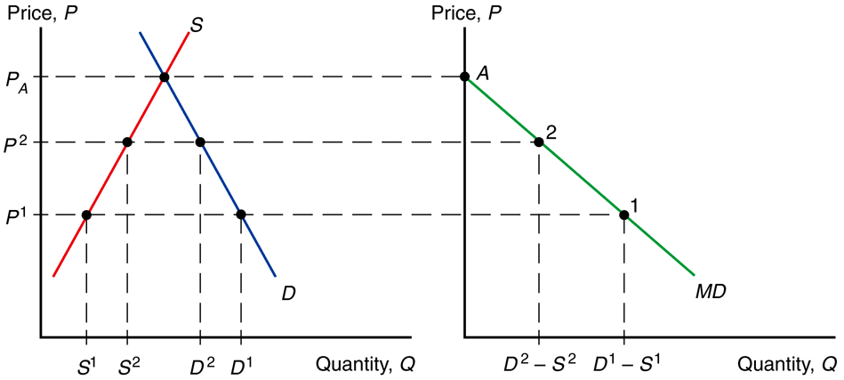

# Supply, Demand, and Trade in a Single Industry

- An **export supply** curve is the difference between the quantity that Foreign producers supply minus the quantity that Foreign consumers demand, at each price.
- The Foreign export supply curve $XS^* = S^* – D^*$ intersects the price axis at $P_A^*$ and is upward sloping:
  - As price increases, the quantity of exports supplied rises.

# Deriving Foreign’s Export Supply Curve

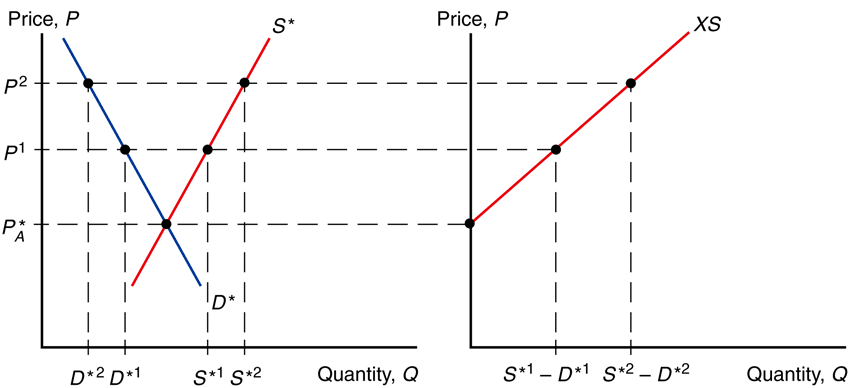

# Supply, Demand, and Trade in a Single Industry

- In equilibrium,
  - import demand = export supply,
  - home demand – home supply = foreign supply – foreign demand,
  - home demand + foreign demand = home supply + foreign supply,
  - world demand = world supply.

# World Equilibrium

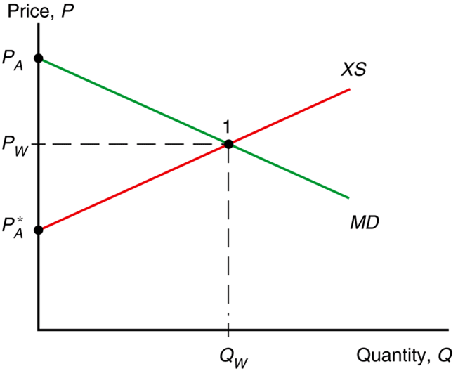

# The Effects of a Tariff

- A tariff acts like a transportation cost, making sellers unwilling to ship goods unless the Home price exceeds the Foreign price by the amount of the tariff: $P_T – t = P_T^*$
- A tariff makes the price rise in the Home market and fall in the Foreign market.

# Effects of a Tariff

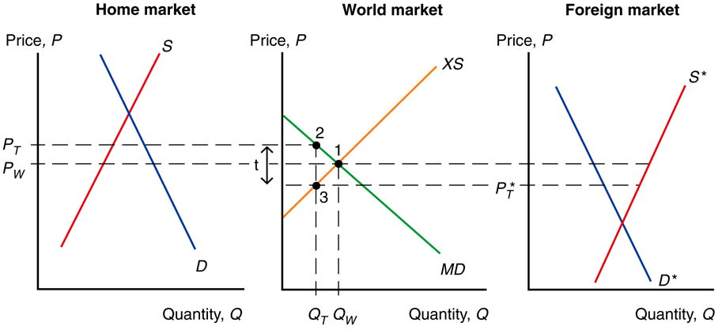

# The Effects of a Tariff

- Because the price in the Home market rises from $P_W$ under free trade to $P_T$ with the tariff,
  - Home producers supply more and Home consumers demand less, so
  - the quantity of imports falls from $Q_W$ under free trade to $Q_T$ with the tariff.

# The Effects of a Tariff

- Because the price in the Foreign market falls from $P_W$ under free trade to $P_T^*$ with the tariff,
  - Foreign producers supply less, and Foreign consumers demand more, so
  - the quantity of exports falls from $Q_W$ to $Q_T$.

# The Effects of a Tariff

- The quantity of Home imports demanded equals the quantity of Foreign exports supplied when $P_T – P_T^* = t$
- The increase in the price in Home can be less than the amount of the tariff.
  - Part of the effect of the tariff causes the Foreign export price to decline.
  - But this effect is sometimes very small.

# The Effects of a Tariff in a Small Country

- When a country is “small,” it has no effect on the foreign (world) price because its demand is an insignificant part of world demand for the good.
  - The foreign price does not fall, but remains at $P_W$.
  - The price in the home market rises by the full amount of the tariff, to $P_T = P_W + t$.

# A Tariff in a Small Country

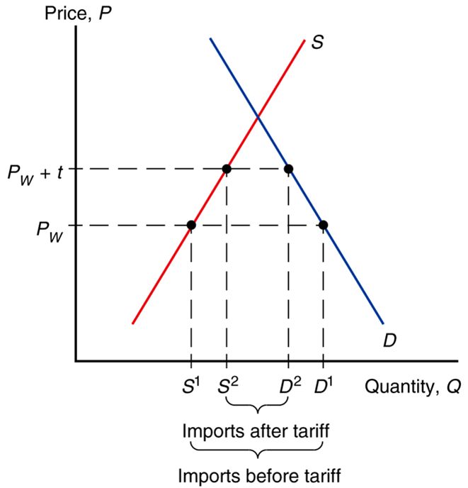

# Effective Rate of Protection

- The **effective rate of protection** measures how much protection a tariff (or other trade policy) provides.
  - It represents the change in value that firms in an industry add to the production process when trade policy changes, which depends on the change in prices the trade policy causes.
- Effective rates of protection often differ from tariff rates because tariffs affect sectors other than the protected sector, causing indirect effects on the prices and value added for the protected sector.

# Effective Rate of Protection

- For example, suppose that automobiles sell in world markets for $8,000, and they are made from factors of production worth $6,000.
  - The value added of the production process is $8,000 – $6,000.
- Suppose that a country puts a 25% tariff on imported autos so that home auto assembly firms can now charge up to $10,000 instead of $8,000.

# Effective Rate of Protection

- The effective rate of protection for home auto assembly firms is the change in value added: $(\$4,000 – \$2,000)/\$2,000 = 100%$
- In this case, the effective rate of protection is greater than the tariff rate.

# Costs and Benefits of a Tariff

# Costs and Benefits of Tariffs

- A tariff raises the price of a good in the importing country, so it hurts consumers and benefits producers there.
- In addition, the government gains tariff revenue.
- How to measure these costs and benefits?
- Use the concepts of consumer surplus and producer surplus.

# Consumer Surplus

- **Consumer surplus** measures the amount that consumers gain from purchases by computing the difference in the price actually paid from the maximum price they would be willing to pay for each unit consumed.
  - When price increases, the quantity demanded decreases as well as the consumer surplus.

# Deriving CS from the Demand

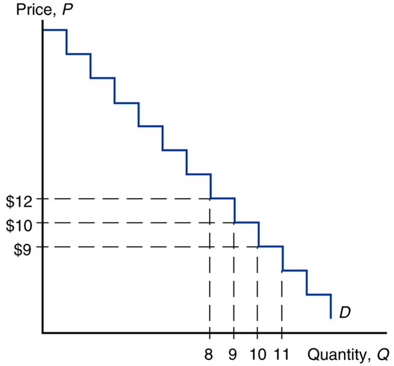

# Geometry of CS

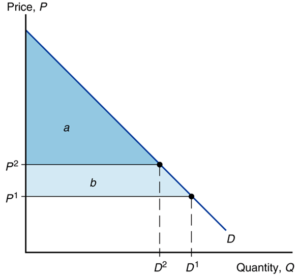

# Producer Surplus

- **Producer surplus** measures the amount that producers gain from sales by computing the difference in the price received from the minimum price at which they would be willing to sell.
  - When price increases, the quantity supplied increases as well as the producer surplus.

# Geometry of PS

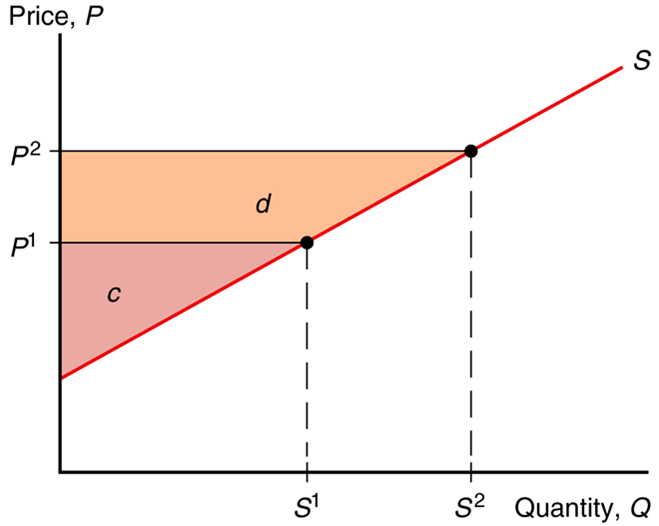

# Costs and Benefits of Tariffs

- A tariff raises the price in the importing country:
  - consumer surplus decreases (consumers worse off)
  - producer surplus increases (producers better off).
  - the government collects tariff revenue equal to the tariff rate times the quantity of imports with the tariff. $tQ_T = (P_T – P_T^* )(D_2 – S_2)$
- Change in welfare due to the tariff is *e – (b + d)*.

# Costs and Benefits of a Tariff for the Importing Country

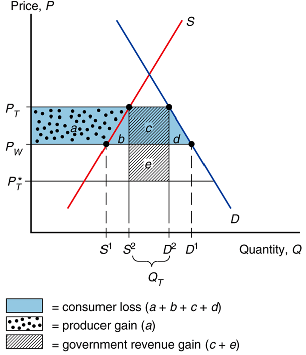

# Costs and Benefits of Tariffs

- For a “large” country, whose imports and exports affect world prices, the welfare effect of a tariff is ambiguous.
- The triangles *b* and *d* represent the **efficiency loss**.
  - The tariff distorts production and consumption decisions: producers produce too much and consumers consume too little.
- The rectangle *e* represents the **terms of trade gain**.
  - The tariff lowers the Foreign price, allowing Home to buy its imports cheaper.

# Costs and Benefits of Tariffs

- Part of government revenue (rectangle *e*) represents the terms of trade gain, and part (rectangle *c*) represents some of the loss in consumer surplus.
  - The government gains at the expense of consumers and foreigners.
- If the terms of trade gain exceed the efficiency loss, then national welfare will increase under a tariff, at the expense of foreign countries.
  - However, foreign countries are apt to retaliate.

# Net Welfare Effects of a Tariff

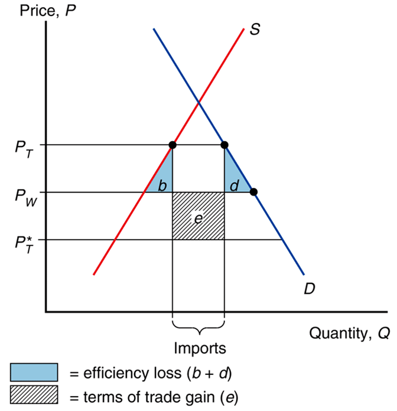

# Other Instruments of Trade Policy

# Export Subsidy

- An export subsidy can also be *specific* or *ad valorem*:
  - A specific subsidy is a payment per unit exported.
  - An ad valorem subsidy is a payment as a proportion of the value exported.
- An export subsidy raises the price in the exporting country, decreasing its consumer surplus (consumers worse off) and increasing its producer surplus (producers better off).

# Export Subsidy

- Also, government revenue falls due to paying $SX_S^*$ for the export subsidy.
- An export subsidy lowers the price paid in importing countries $P_S^* = P_S – S$.
- In contrast to a tariff, an export subsidy worsens the terms of trade by lowering the price of exports in world markets.

# Effects of an Export Subsidy

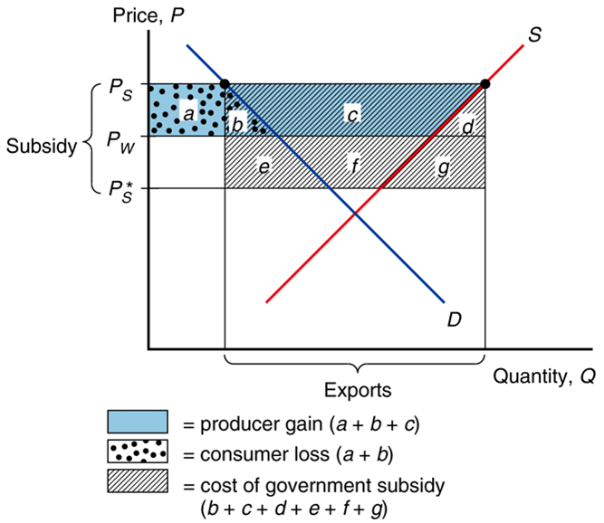

# Export Subsidy

# Export Subsidy in Europe

- The European Union’s Common Agricultural Policy sets high prices for agricultural products and subsidizes exports to dispose of excess production.
  - The subsidized exports reduce world prices of agricultural products.
- The cost of this policy for European taxpayers is almost $30 billion more than its benefits (in 2007).
  - But the EU has proposed that farmers receive direct payments independent of the amount of production to help lower EU prices and reduce production.

# Europe’s Common Agricultural Program

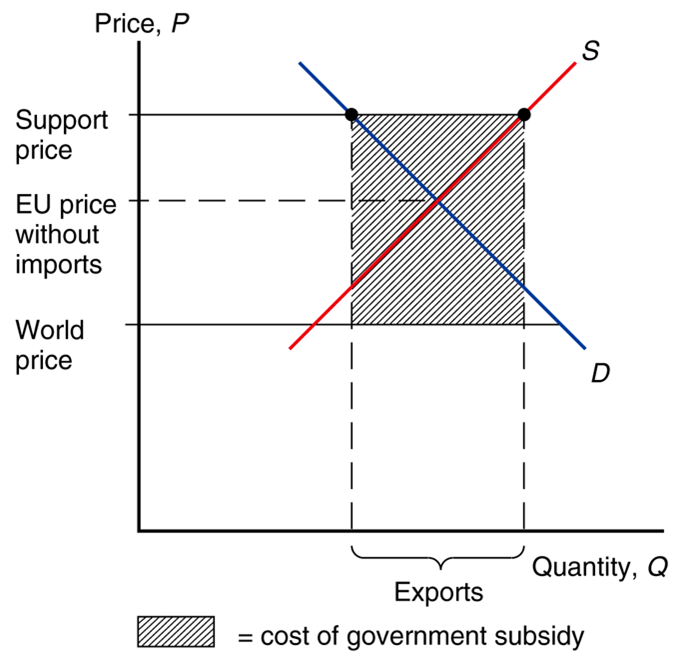

# Import Quota

- An import quota is a restriction on the quantity of a good that may be imported.
- This restriction is usually enforced by issuing licenses or quota rights.
- A binding import quota will push up the price of the import because the quantity demanded will exceed the quantity supplied by Home producers and from imports.

# Import Quota

- When a quota instead of a tariff is used to restrict imports, the government receives no revenue.
  - Instead, the revenue from selling imports at high prices goes to quota license holders.
  - These extra revenues are called **quota rents**.

# Effects of the U.S. Import Quota on Sugar

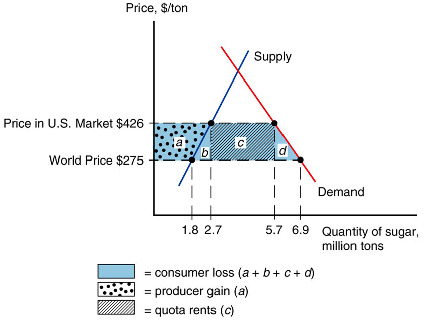

# Voluntary Export Restraint

- A **voluntary export restraint** works like an import quota, except that the quota is imposed by the exporting country rather than the importing country.
- These restraints are usually requested by the importing country.
- The profits or rents from this policy are earned by foreign governments or foreign producers.
  - Foreigners sell a restricted quantity at an increased price.

# Local Content Requirement

- A **local content requirement** is a regulation that requires a specified fraction of a final good to be produced domestically.
- It may be specified in value terms, by requiring that some minimum share of the value of a good represent home value added, or in physical units.

# Local Content Requirement

- From the viewpoint of domestic producers of inputs, a local content requirement provides protection in the same way that an import quota would.
- From the viewpoint of firms that must buy home inputs, however, the requirement does not place a strict limit on imports, but allows firms to import more if they also use more home parts.

# Local Content Requirement

- Local content requirement provides neither government revenue (as a tariff would) nor quota rents.
- Instead, the difference between the prices of home goods and imports is averaged into the price of the final good and is passed on to consumers.

# Other Trade Policies

- Export credit subsidies
  - A subsidized loan to exporters
  - U.S. Export-Import Bank subsidizes loans to U.S. exporters.
- Government procurement
  - Government agencies are obligated to purchase from home suppliers, even when they charge higher prices (or have inferior quality) compared to foreign suppliers.
- Bureaucratic regulations
  - Safety, health, quality, or customs regulations can act as a form of protection and trade restriction.

# The Effects of Trade Policy

- For each trade policy, the price rises in the Home country adopting the policy.
  - Home producers supply more and gain.
  - Home consumers demand less and lose.
- The world price falls when Home is a “large” country that affects world prices.
- Tariffs generate government revenue; export subsidies drain it; import quotas do not affect government revenue.
- All these trade policies create production and consumption distortions.

# Effects of Alternative Trade Policies

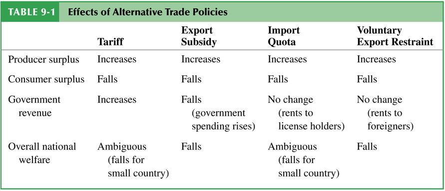

# Summary

# Summary

1. A tariff increases the home price and the quantity supplied and reduces the quantity demanded and the quantity traded; also decreases the world price when the country is “large.”
2. A quota does the same; an export subsidy does the same.
3. Tariffs generate government revenue; export subsidies drain it; import quotas are revenue neutral.

# Summary

4. The welfare effect of a tariff, quota, or export subsidy can be measured by
   - efficiency loss from consumption and production distortions.
   - terms of trade gain or loss.
5. With import quotas, voluntary export restraints, and local content requirements, the government of the importing country receives no revenue.
6. With voluntary export restraints and occasionally import quotas, quota rents go to foreigners.